# Potential Cut to Social Security Administration Spending

Isabelle Farina

2026-06-05

Isabelle Farina,isabellefarina546@gmail.com, 6/5/2026

### What is this story about?

New Jersey is consistently [one of the most expensive states to live in](https://worldpopulationreview.com/state-rankings/cost-of-living-index-by-state), and not just because of its proximity to New York City, delicious restaurants and luxurious beaches. In fact, most of the benefits of living in the “armpit of America” come later in life with social security benefits.

**According to the** **Congressional Budget Office,** Social Security is less than seven years away from insolvency. If that occurs, there **could be a** a 24% across-the-board benefit cut. In all 21 counties of New Jersey, the Social Security Administration **provides** the most federal spending. This would make potential cuts to benefits all the more stinging.

**This story proposal examines what a reduction in Social Security spending would look like in each county in New Jersey.**

[figure not shown]

Before diving into NJ, let’s analyze the U.S. All 50 states have spent at least a total of $10 billion on SSA from 2020-2024.

### Federal Spending on Social Security Administration By State

```r
federal_spending <- read_csv("https://raw.githubusercontent.com/djnf-data-2026/master/refs/heads/main/data/federal_spending_by_county_2020%202024%20rob_0416_v2.csv")
nj_spending <- federal_spending |>
  filter(state_nm == "NEW JERSEY")
```

This table demonstrates the top 15 states with the most federal spending on the Social Security Administration. New Jersey is ranked number 11 with $180.06 billion **from 2020-2024**. While this is significantly less than California’s $620.75 billion, it is pretty high for a small state.

```r
state_spending <- federal_spending %>%
group_by(state_nm) |>
  filter(agency=="Social Security Administration") |>
  summarize(
    total_spent = sum(spending_total, na.rm = TRUE)) |>
   mutate(`total_spent_$` = scales::dollar(total_spent / 1e9, suffix = "B", accuracy = 0.01)) |>
  arrange(desc(total_spent))
print(state_spending, n = 15)
```

```
## # A tibble: 61 × 3
##    state_nm        total_spent `total_spent_$`
##    <chr>                 <dbl> <chr>
##  1 CALIFORNIA     620753260226 $620.75B
##  2 FLORIDA        493870979946 $493.87B
##  3 TEXAS          439430386088 $439.43B
##  4 NEW YORK       380264187455 $380.26B
##  5 PENNSYLVANIA   295353400906 $295.35B
##  6 OHIO           236113888397 $236.11B
##  7 MICHIGAN       234046132079 $234.05B
##  8 ILLINOIS       230744021757 $230.74B
##  9 NORTH CAROLINA 220310999741 $220.31B
## 10 GEORGIA        190128659545 $190.13B
## 11 NEW JERSEY     180064526916 $180.06B
## 12 VIRGINIA       164352179277 $164.35B
## 13 WASHINGTON     148021752736 $148.02B
## 14 ARIZONA        147888070490 $147.89B
## 15 TENNESSEE      147553635191 $147.55B
## # ℹ 46 more rows
```

However, it is important to analyze spending per capita. Per captia means dividing the total amount by the number of individuals in a population, allowing for fair comparisons across groups of different sizes. New Jersey is actually ranked 33 for SSA spending per capita. Nonetheless, New Jersey’s large population and high sums spent on SSA make potential cuts worth analyzing.

[interactive chart not shown]

spening per capita

```r
pop <- read_csv("../data/population_inc_2024.csv") %>%
  mutate(state1 = str_to_upper(NAME)) %>%
  select(state1, estimate)
#add population
state_spending1 <- state_spending %>%
  inner_join(pop, by=c("state_nm" = "state1")) %>%
  rename(population = estimate) %>%
  mutate(spending_per_capita = (total_spent/population)) %>%
  arrange(desc(spending_per_capita)) %>%
  mutate(rank = row_number())

write_csv(state_spending1,("state_spending1.csv"))
```

### In one sentence, why tell this story NOW?

This story is relevant because there have been [significant changes](https://www.aarp.org/social-security/biggest-2026-changes/) in the last year to what Social Security entails, and people need clarity on what this means, especially if even larger cuts are coming in the near future.

### Who is your target audience?

- Folks of benefit-earning age who have been paying Social Security taxes in NJ their whole lives and want to ensure they rightfully receive their benefits
- Younger families who want to know if it is worth it in the long run to live in a state as expensive as NJ
- Disabled/financially insecure people who currently benefit from Social Security

### Three people you can interview for this story

- An NJ official who is involved and knowledgeable on NJ’s budget and federal spending on Social Security Administration
  - New Jersey Governor Mikie Sherrill, Phone: (609) 292-6000
  - Regional Commissioner of Social Security Administration for NJ/NY Region Raymond Egan
  - Director of Economic Justice and Public Benefits Clinic at Rutgers University Jon Dubin
    - How will Supplemental Security Income (SSI) be impacted? Economic justice?
- A local resident currently receiving and dependent on Social Security benefits
  - Do they purposely live in NJ?
  - How have their benefits changed recently? Why should states value Social Security?
- A local resident who pays taxes
  - Do they know what benefits they are entitled to?

### Potential impact

Nationally, Social Security is experiencing drastic changes, and it is important to narrow our focus on how these adjustments affect New Jersey, along with how the state’s high federal spending on the Social Security Administration mitigates or worsens these effects.

```r
county_spending <- nj_spending |>
group_by(cty_name) |>
  filter(agency=="Social Security Administration") |>
  summarize(
    total_spent = sum(spending_total, na.rm = TRUE)) |>
   mutate(`total_spent_$` = scales::dollar(total_spent / 1e9, suffix = "B", accuracy = 0.01)) |>
  arrange(desc(total_spent))
print(county_spending, n = 21)
```

```
## # A tibble: 22 × 3
##    cty_name   total_spent `total_spent_$`
##    <chr>            <dbl> <chr>
##  1 BERGEN     18829382144 $18.83B
##  2 OCEAN      17374930944 $17.37B
##  3 MIDDLESEX  14982395904 $14.98B
##  4 MONMOUTH   14795062528 $14.80B
##  5 ESSEX      12637870848 $12.64B
##  6 CAMDEN     10609140608 $10.61B
##  7 MORRIS     10551322368 $10.55B
##  8 BURLINGTON 10320207744 $10.32B
##  9 UNION       9328520192 $9.33B
## 10 PASSAIC     8795635840 $8.80B
## 11 HUDSON      7667564800 $7.67B
## 12 MERCER      7369237888 $7.37B
## 13 SOMERSET    6633176960 $6.63B
## 14 GLOUCESTER  6554120960 $6.55B
## 15 ATLANTIC    6402366464 $6.40B
## 16 SUSSEX      3488140352 $3.49B
## 17 HUNTERDON   3194011968 $3.19B
## 18 CAPE MAY    3141464192 $3.14B
## 19 CUMBERLAND  3111079296 $3.11B
## 20 WARREN      2630853760 $2.63B
## 21 SALEM       1639818432 $1.64B
## # ℹ 1 more row
```

# Total Spending By County for Social Security Administration

This interactive map demonstrates all 21 counties and their per capita receipts for Social Security. Cape May County has the most with $35,065.68, while Hudson County has the least with $12,359.68.

[interactive chart not shown]

### What are three things that surprised or interested you about this story?

I was not aware of how much Social Security encompasses. It goes far beyond old people receiving benefits, and includes things like Supplemental Security Income. In New Jersey, Social Security administers the State supplement of the Federal SSI benefit with additional payments. Additionally, I was not fully aware of how much change Social Security is undergoing recently. I want to be able to connect the trend of every NJ county having SSA as its number one agency for federal spending to the national changes.

### Context: Summarize any previous coverage + What other information do you need to gather?

[Social Security benefit cuts could be coming — and there’s an actual date attached](https://www.nj.com/news/2026/04/social-security-benefit-cuts-could-be-coming-and-theres-an-actual-date-attached.html)

- The Congressional Budget Office is saying that Social Security could run out of money a year sooner in 2032 due to a provision in the One Big Beautiful Bill Act. To address this budget shortfall, there are proposals to make cuts to Social Security.

## How does this intersect with NJ’s federal spending?

```r
nj <- read_csv("../data/nj_update.csv")
nj_county_pop <- nj |> select(cty_name, county_pop) |> distinct()
```

```r
county_sums <- county_spending |>
  inner_join(nj_county_pop)
per_capita <- county_sums |> mutate(per_capita=total_spent/county_pop)
```

```r
per_capita <- per_capita |>
  mutate(spending_reduce=total_spent-(total_spent * 0.24))
```

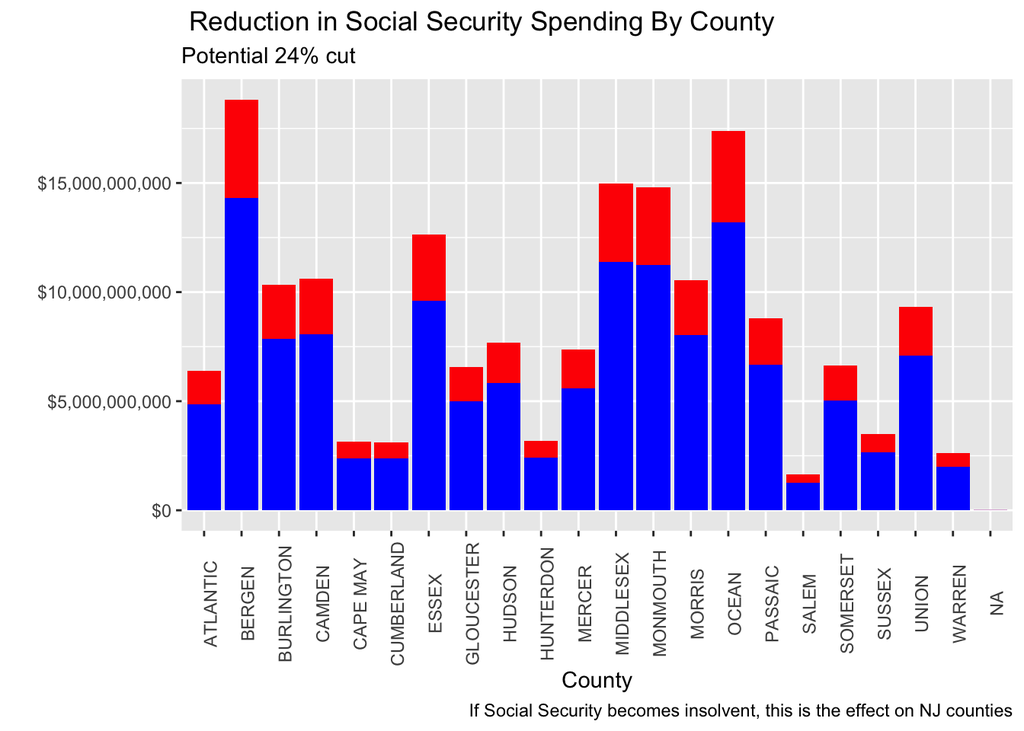

```r
options(scipen=999)
ggplot(per_capita,aes(x = cty_name)) +
  geom_col(aes(y = total_spent), fill = "red") +
    geom_col(aes(y = spending_reduce), fill = "blue") +
  theme(axis.text.x=element_text(angle=90)) +
 scale_y_continuous(labels = scales::dollar) +
  #geom_text(aes(label = scales::percent(percent)), size = 4) +
  labs(title = " Reduction in Social Security Spending By County",
       subtitle = "Potential 24% cut",
       caption = "If Social Security becomes insolvent, this is the effect on NJ counties",
       y="",
       x="County")
```

[Social Security’s proposed rule change could cut benefits for nearly 400K disabled people. Here’s why](https://www.nj.com/news/2026/05/social-securitys-proposed-rule-change-could-cut-benefits-for-nearly-400k-disabled-people-heres-why.html)

- The Social Security Administration would remove Supplemental Nutrition Assistance Program (SNAP) benefits as a qualification to receive Supplemental Security Income (SSI) and tighten the qualifications for what is deemed a “public assistance household,” according to an Executive Order submission currently under review.
  - What does this mean for NJ, a state that directs most of its federal spending towards the Social Security Administration?

[Social Security COLA 2027 projection released, and the amount may surprise you](https://www.nj.com/news/2026/04/social-security-cola-2027-projection-released-and-the-amount-may-surprise-you.html)

- According to the Senior Citizens League, the 2027 cost of living assessment will remain flat at 2.8%, the same as it was in 2026.
  - How do citizens feel about this?

```r
federal_spending <- read_csv("../data/federal spending by county 2020-2024.csv")
nj_spending <- federal_spending |>
  filter(state_nm == "NEW JERSEY")
```

#Population

```r
#DONT NEED THIS LINE - ALREADY IMPORTED IT
#nj <- read_csv("../data/nj_update.csv")
nj_county_pop <- nj |> select(cty_name, county_pop) |> distinct()
```

```r
per_capita <- per_capita |>
  mutate(spending_reduce=total_spent-(total_spent * 0.24))
```

```r
county_sums <- county_spending |>
  inner_join(nj_county_pop)
per_capita <- county_sums |> mutate(per_capita=total_spent/county_pop)
```

```r
per_capita <- per_capita |>
  mutate(spending_reduce=total_spent-(total_spent * 0.24))
```

### Potential Holes

It is important to acknowledge that census data is ever-changing. Data is an approximation, and no data-set is completely fixed. Additionally, this spending information is from 2020-2024, meaning the affect of the potential cut will change as the spending changes year to year.

### Impacted Businesses

One company relevant to changes to Social Security benefits would be the medical company Johnson & Johnson, which has a prescription-drug benefits program. However, [several cases have been filed in various state courts of New Jersey](https://www.sec.gov/Archives/edgar/data/200406/000020040626000016/jnj-20251228.htm), specifically multi-county litigation in Bergen County. The cases are the result of using ELMIRON, a prescription medication for the relief of bladder pain. In addition to legal updates, medical companies like Johnson & Johnson are important to watch amidst changes to Social Security.

### Estimated delivery

In order to conduct thorough interviews with several local residents who bring different perspectives to the story, interview a knowledgeable expert on NJ finances who may be difficult to contact and compile data into pleasing visualizations, I anticipate this assignment to take me two to three weeks.